## Matching points to census tracts

Researchers often have point data that they want to append census tracts to for social science research. This guide shows you how to do this using a handful of R packages.

### Step I: Libraries and setup

The libraries you will need to complete this project are listed below. You will want to install and/or load in the R packages before beginning.

```r
library(tidyverse)
library(sf)
library(cowplot)
library(leaflet)
library(magrittr)
library(rgdal)
library(tigris)
options(tigris_use_cache = TRUE)
options(scipen = 999)
```

### Step II: Reading in data

Read in point data, either from your local system file explorer (first example) or with a geoJSON API address (second example) using the [sf package](https://r-spatial.github.io/sf/). The `sf` stands for “simple features,” an international standardization for storing geospatial data in a database. Simple feature geometries can be read by many different systems, including QGIS, ArcGIS, and R. By reading in the point data with the `sf` pacakge, the imported data frame will have a geometry column.

We will use the Capital Bikeshare station location geoJSON file from the open data DC portal for this example, which can be accessed [here](https://opendata.dc.gov/datasets/capital-bike-share-locations).

```r
point_data <- st_read("Point/to/File.csv", options = c("X_POSSIBLE_NAMES = x","Y_POSSIBLE_NAMES = y"))
```

OR

```r
point_data <- st_read("https://opendata.arcgis.com/datasets/a1f7acf65795451d89f0a38565a975b3_5.geojson")
```

Be aware that if the geoJSON link is coming from a Socrata Open Data API ([SODA](https://www.tylertech.com/products/socrata/data-platform)), the link will only pull the first [1,000 records](https://dev.socrata.com/docs/queries/limit.html), and `?$limit=number` should be added to the end of the url to pull the records you need. There are timeout issues if the data is too large, so it might be more efficient to download the csv and use the first code example to load the data into RStudio. When you load the data from a csv, you just have to point to the geometry fields by replacing the `x` and `y` in the first example to correspond to your latitude and longitude columns.

### Step III: Getting geographies

Additionally, since the implementation of FIPS codes, several counties have experienced FIPS code changes. Depending on when the data was collected, you should check to ensure the codes are [still accurate](https://www.census.gov/programs-surveys/geography/technical-documentation/county-changes.html).

For this example, we will create an object with all of the state FIPS codes except for 56, the FIPS code for the United States Minor Outlying Islands (UM), which [do not have](https://www.census.gov/history/www/programs/geography/island_areas.html) census tracts:

```r
location <- unique(fips_codes$state)[-56]
```

Next, you want to create a data frame of all the tracts from the geography you selected. You will want to ensure you are reading in the tracts in the correct coordinate reference system (CRS), a [standard](https://docs.qgis.org/3.4/en/docs/gentle_gis_introduction/coordinate_reference_systems.html) for determining the correct projection to display the coordinates in. To check what projection your point data are in, use the `st_crs` function in `sf`:

```r
st_crs(point_data)
```

```
## Coordinate Reference System:
##   User input: WGS 84
##   wkt:
## GEOGCRS["WGS 84",
##     DATUM["World Geodetic System 1984",
##         ELLIPSOID["WGS 84",6378137,298.257223563,
##             LENGTHUNIT["metre",1]]],
##     PRIMEM["Greenwich",0,
##         ANGLEUNIT["degree",0.0174532925199433]],
##     CS[ellipsoidal,2],
##         AXIS["geodetic latitude (Lat)",north,
##             ORDER[1],
##             ANGLEUNIT["degree",0.0174532925199433]],
##         AXIS["geodetic longitude (Lon)",east,
##             ORDER[2],
##             ANGLEUNIT["degree",0.0174532925199433]],
##     ID["EPSG",4326]]
```

The census defaults to the CRS 4269, so we want to make sure we read in any census tract data with a 4326 CRS. To read in the tracts, we want to create an object that feeds the `rbind` function from `sf` to `purrr`’s `reduce` function, which [allows us](https://walker-data.com/2017/05/tidycensus-every-tract/) to map the census tracts.

```r
get_tracts <- function(x){
  tracts(state = x, cb = FALSE, class = "sf")
  }

census_tracts <- reduce(map(location, get_tracts), rbind)

census_tracts <- st_transform(census_tracts, crs = 4326)
```

### Step IV: Join the points and census tracts

The last step in matching the points to census tracts before checking for errors is joining the point data to the census tracts using `st_join`, an `sf` function which joins two data frames by a common field. We want to use `st_intersects`, which checks to see if the geometries in `x` (`point_data`) and `y` (`census_tracts`) share any space. If they do, it adds the rows together:

```r
joined_data <- st_join(point_data, census_tracts, join = st_intersects)
```

### Step V: Check linkages

Then you want to check to see if there are any empty rows where points didn’t match to tracts:

```r
joined_data[is.na(joined_data$TRACTCE),]
```

```
## Simple feature collection with 0 features and 29 fields
## bbox:           xmin: NA ymin: NA xmax: NA ymax: NA
## geographic CRS: WGS 84
##  [1] OBJECTID              ID                    ADDRESS
##  [4] TERMINAL_NUMBER       LATITUDE              LONGITUDE
##  [7] INSTALLED             LOCKED                INSTALL_DATE
## [10] REMOVAL_DATE          TEMPORARY_INSTALL     NUMBER_OF_BIKES
## [13] NUMBER_OF_EMPTY_DOCKS X                     Y
## [16] SE_ANNO_CAD_DATA      OWNER                 STATEFP
## [19] COUNTYFP              TRACTCE               GEOID
## [22] NAME                  NAMELSAD              MTFCC
## [25] FUNCSTAT              ALAND                 AWATER
## [28] INTPTLAT              INTPTLON              geometry
## <0 rows> (or 0-length row.names)
```

Another way to check for linkage errors is to visualize the joined data on a map. To ensure you don’t have a map of the entire world, save the bounding box coordinates for `point_data` (it has to be coerced to a numeric class before it can be transformed into a data frame):

```r
bbox_coords <- st_bbox(point_data) %>% as.numeric() %>% as.data.frame()
bbox_x <- bbox_coords[c(1,3),]
bbox_y <- bbox_coords[c(2,4),]
```

Then plot it to a map to check for outliers:

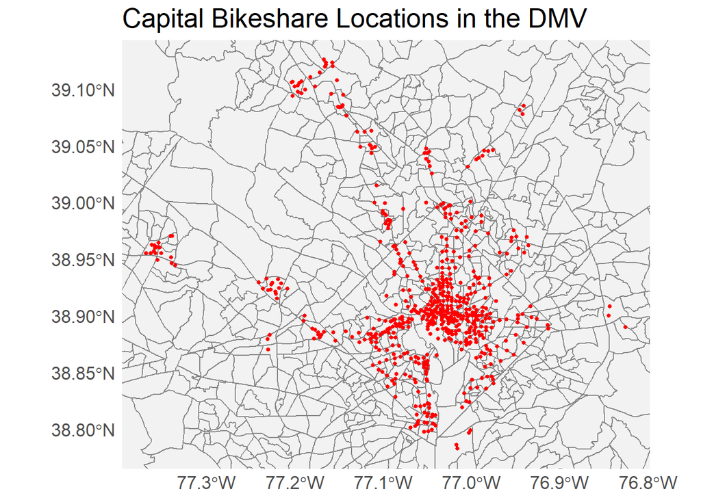

```r
ggplot() +
  geom_sf(data = census_tracts, color = "#868686", fill = "#f2f2f2") +
  ggtitle("Capital Bikeshare Locations in the DMV") +
  geom_sf(data = point_data, size = 1, shape = 16, col = "red") +
  coord_sf(xlim = bbox_x, ylim = bbox_y) +
  theme(text=element_text(size=16),
        axis.title.x = element_blank(),
        axis.title.y = element_blank(),
        axis.line = element_blank(),
        axis.ticks = element_blank())
```

### Step VI: Save the table

You have now created a table with the points and census tracts. You can export `joined_data` as a csv, a geoJSON, a geopackage, a shapefile, and [more](https://gdal.org/drivers/vector/index.html):

```r
st_write(joined_data, "Data/joined_data.geoJSON")
```

## Bibliography and References

JJ Allaire, Yihui Xie, Jonathan McPherson, Javier Luraschi, Kevin Ushey, Aron Atkins, Hadley Wickham, Joe Cheng and Winston Chang (2017). rmarkdown: Dynamic Documents for R. R package version 1.8. https://CRAN.R-project.org/package=rmarkdown

Kyle Walker (2017). Getting data for every Census tract in the US with purrr and tidycensus. http://walker-data.com/2017/05/tidycensus-every-tract/

Yihui Xie (2017). knitr: A General-Purpose Package for Dynamic Report Generation in R. R package version 1.18.